# coyote_figures script

authors: Jamie Clarke, , Marissa Dyck, Larissa Bron, Madison Carlson, Sophia Labiy, Zoe Penno, Hayley Webster, Jason T Fisher

last updated: 30/12/2024

## about

This is walk-through on how to make figures and maps for *the coyote manuscript*. It was written by Jamie Clarke with help from Dr. Marissa Dyck. Before running this script, you will need to format and analyze the data using the coyote_formatting and coyote_analysis scripts. The spatial data required to run the script is available on Jamie’s GitHub at https://github.com/jfclarke/osm_coyote_glmm, or in the links provided. Happy figure- and map-making :-)

## 1) set-up

#### start by loading in relevant packages:

```r
library(tidyverse)
library(PerformanceAnalytics)
library(ggplot2)
library(cowplot)
library(sf)
library(dplyr)
library(tmap)
library(tmaptools)
library(ggpubr)
library(grid)
library(sp)
library(lme4)
library(ggeffects)
library(scales)
library(rphylopic)
library(MuMIn)
```

#### and setting the ggplot theme

```r
theme_set(theme_classic())
```

## 2) data import

#### a) read in processed data (created using coyote_formatting script):

```r
coyote_data <-

  read_csv('data/processed/coyote_data.csv') %>%

  # add wide_linear column combining all wide linear features (determined using coyote_analysis script)
  mutate(wide_linear =
           roads +
           seismic_lines +
           transmission_lines)
```

#### b) run top model (determined using coyote_analysis script):

```r
global <-

  glmer(
    cbind(coyote_pres, coyote_abs) ~
      scale(nat_land) +
      scale(wide_linear) +
      scale(white_tailed_deer) +
      scale(moose) +
      scale(red_squirrel) +
      scale(snowshoe_hare) +
      scale(grey_wolf) +
      scale(lynx) +
      scale(fisher) +
      (1 | array),
    data = coyote_data,
    family = binomial)
```

## 3) calculating odds ratios

```r
global_odds <-

  # calculate confidence intervals
  confint(global,
          parm = 'beta_') %>%

  # extract fixed effects coefficients
  cbind(est = fixef(global)) %>%

  # exponentiate to get odds ratios
  exp() %>%

  as.data.frame() %>%

  # name first column and preserve it for next step
  rownames_to_column(var = 'term') %>%

  # convert to tibble for easier manipulation
  as_tibble() %>%

  # remove intercept information
  filter(term != '(Intercept)') %>%

  # rename confidence %s
  rename(lower = '2.5 %',
         upper = '97.5 %') %>%

  # add a column with cleaned-up plot label names (so we don't have to do this in ggplot2)
  add_column(label = c('natural landcover',
                       'wide linear features',
                       'white-tailed deer',
                       'moose',
                       'red squirrel',
                       'snowshoe hare',
                       'grey wolf',
                       'lynx',
                       'fisher')) %>%

  # change label column into a factor for plotting
  mutate(label = as.factor(label)) %>%

  # add column for whether error bars overlap with 1 (for plotting)
  add_column(overlap = c('N',
                         'N',
                         'Y',
                         'Y',
                         'Y',
                         'N',
                         'N',
                         'N',
                         'Y'))
```

## 4) odds ratios plot

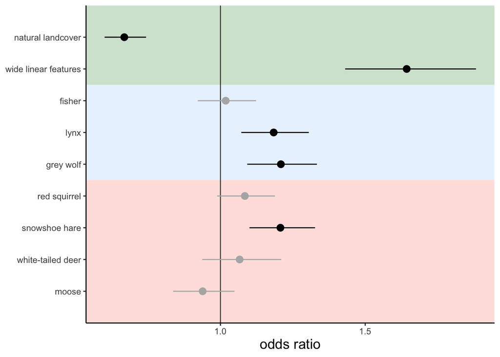

```r
odds_plot <-

  ggplot(data = global_odds %>%

           # customize order of labels
           mutate(label = fct_relevel(label,
                                      'natural landcover',
                                      'wide linear features',
                                      'fisher',
                                      'lynx',
                                      'grey wolf',
                                      'red squirrel',
                                      'snowshoe hare',
                                      'white-tailed deer',
                                      'moose')),
         aes(x = label,
             y = est,
             color = overlap)) +

  # add background for landscape covariates
  annotate('rect',
           xmin = 7.5,
           xmax = 10,
           ymin = -Inf,
           ymax = Inf,
           fill = 'darkseagreen',
           alpha = 0.4) +

  # add background for competitor covariates
  annotate('rect',
           xmin = 4.5,
           xmax = 7.5,
           ymin = -Inf,
           ymax = Inf,
           fill = 'lightsteelblue1',
           alpha = 0.4) +

  # add background for prey covariates
  annotate('rect',
           xmin = 0,
           xmax = 4.5,
           ymin = -Inf,
           ymax = Inf,
           fill = 'tomato',
           alpha = 0.2) +

  # add line at 1
  geom_hline(yintercept = 1,
             alpha = 0.7) +

  # add points for estimates
  geom_point(size = 3) +

  # add confidence intervals
  geom_linerange(aes(ymin = lower,
                     ymax = upper),
                 linewidth = 0.5) +

  # set colour based on whether error bars overlap with 1
  scale_color_manual(values = c('black', 'grey70' ),
                     labels = c('N', 'Y')) +

  # reverse the order of labels on the x axis (ggplot annoyingly plots them in reverse order)
  scale_x_discrete(limits = rev) +

  # rename y axis title
  ylab('odds ratio') +

  # flip x and y axis
  coord_flip() +

  # specify theme elements
  theme(panel.grid = element_blank(),
        axis.title.y = element_blank(),
        legend.position = 'none',
        axis.title.x = element_text(size = 14))

# run odds_plot to see figure
odds_plot
```

## 5) export odds ratio plot

#### save odds_plot to ‘figures’ folder:

```r
ggsave('odds_ratio_plot.tiff',
       odds_plot,
       path = 'figures')
```

## 6) determining predicted probabilities

#### predicted probabilities given each covariates of interest:

```r
pp_nat_land <-

  ggpredict(global,
            terms = 'nat_land [all]',
            type = 'fe') # fe = fixed effects

pp_wide_linear <-

  ggpredict(global,
            terms = 'wide_linear [all]',
            type = 'fe')

pp_moose <-

  ggpredict(global,
            terms = 'moose [all]',
            type = 'fe')

pp_red_squirrel <-

  ggpredict(global,
            terms = 'red_squirrel [all]',
            type = 'fe')

pp_snowshoe_hare <-

  ggpredict(global,
            terms = 'snowshoe_hare [all]',
            type = 'fe')

pp_white_tailed_deer <-

  ggpredict(global,
            terms = 'white_tailed_deer [all]',
            type = 'fe')

pp_fisher <-

  ggpredict(global,
            terms = 'fisher [all]',
            type = 'fe')

pp_grey_wolf <-

  ggpredict(global,
            terms = 'grey_wolf [all]',
            type = 'fe')

pp_lynx <-

  ggpredict(global,
            terms = 'lynx [all]',
            type = 'fe')
```

## 7) predicted probabilities plots

#### side note: to find the PhyloPic uuid (= image ID), type the following code in the console:

```r
pick_phylopic(name = 'Alces alces', n = 2) # or whatever other species/number
```

#### where name is the scientific or common name of the species of interest and n is the number of options you want to peruse; when you find the image you want, select it and find the uuid in the console output

plot predicted probability of coyote occurrence given proportion of natural landcover:

```r
plot_nat_land <-

  ggplot(pp_nat_land,
         aes(x = x,
             y = predicted)) +

  geom_line(aes()) +

  geom_ribbon(aes(ymin = conf.low,
                  ymax = conf.high),
              fill = 'darkseagreen',
              alpha = 0.4) +

  scale_x_continuous(limits = c(0.7, 1),
                     breaks = seq(0.7, 1, by = 0.1),
                     expand = c(0, 0)) +

  scale_y_continuous(limits = c(0, 0.65),
                     breaks = seq(0, 0.65, by = 0.2),
                     expand = c(0, 0)) +

  xlab('proportion natural land') +

  ylab(' ') +

  theme(axis.title.y = element_blank(),
        axis.text = element_text(size = 7),
        axis.title.x = element_text(size = 9),
        axis.title.y.left = element_text(size = 35))
```

plot predicted probability of coyote occurrence given proportion of wide linear features:

```r
plot_wide_linear <-

  ggplot(pp_wide_linear,
         aes(x = x,
             y = predicted)) +

  geom_line(aes()) +

  geom_ribbon(aes(ymin = conf.low,
                  ymax = conf.high),
              fill = 'darkseagreen',
              alpha = 0.4) +

  scale_x_continuous(expand = c(0, 0)) +

  scale_y_continuous(limits = c(0, 0.65),
                     breaks = seq(0, 0.65, by = 0.2),
                     expand = c(0, 0)) +

  xlab('proportion of wide LFs') +

  ylab(' ') +

  theme(axis.title.y = element_blank(),
        axis.text = element_text(size = 7),
        axis.title.x = element_text(size = 9),
        axis.title.y.left = element_text(size = 35))
```

plot predicted probability of coyote occurrence given total independent moose detections:

```r
plot_moose <-

  ggplot(pp_moose,
         aes(x = x,
             y = predicted)) +

  geom_line(aes()) +

  geom_ribbon(aes(ymin = conf.low,
                  ymax = conf.high),
              fill = 'tomato',
              alpha = 0.4) +

  scale_x_continuous(expand = c(0, 0)) +

  scale_y_continuous(limits = c(0, 0.65),
                     breaks = seq(0, 1, by = 0.2),
                     expand = c(0, 0)) +

  xlab('total moose detections') +

  ylab(' ') +

  theme(axis.title.y = element_blank(),
        axis.text = element_text(size = 7),
        axis.title.x = element_text(size = 9),
        axis.title.y.left = element_text(size = 35)) +

  # add moose silhouette
  add_phylopic(uuid = '74eab34a-498c-4614-aece-f02361874f79',
               x = 10,
               y = 0.55,
               height = 0.2)
```

plot predicted probability of coyote occurrence given total independent red squirrel detections:

```r
plot_red_squirrel <-

  ggplot(pp_red_squirrel,
         aes(x = x,
             y = predicted)) +

  geom_line(aes()) +

  geom_ribbon(aes(ymin = conf.low,
                  ymax = conf.high),
              fill = 'tomato',
              alpha = 0.4) +

  scale_x_continuous(limits = c(0, 150),
                     breaks = seq(0, 150, by = 50),
                     expand = c(0, 0)) +

  scale_y_continuous(limits = c(0, 0.65),
                     breaks = seq(0, 1, by = 0.2),
                     expand = c(0, 0)) +

  xlab('total squirrel detections') +

  ylab(' ') +

  theme(axis.title.y = element_blank(),
        axis.text = element_text(size = 7),
        axis.title.x = element_text(size = 9),
        axis.title.y.left = element_text(size = 35)) +

  # add squirrel silhouette
  add_phylopic(uuid = 'dad08fea-5263-4f57-a37b-c27cbe0eb9a5',
               x = 30,
               y = 0.54,
               height = 0.16)
```

plot predicted probability of coyote occurrence given total independent snowshoe hare detections:

```r
plot_snowshoe_hare <-

  ggplot(pp_snowshoe_hare,
         aes(x = x,
             y = predicted)) +

  geom_line(aes()) +

  geom_ribbon(aes(ymin = conf.low,
                  ymax = conf.high),
              fill = 'tomato',
              alpha = 0.4) +

  scale_x_continuous(expand = c(0,0)) +

  scale_y_continuous(limits = c(0, 0.65),
                     breaks = seq(0, 1, by = 0.2),
                     expand = c(0, 0)) +

  xlab('total hare detections') +

  ylab(' ') +

  theme(axis.title.y = element_blank(),
        axis.text = element_text(size = 7),
        axis.title.x = element_text(size = 9),
        axis.title.y.left = element_text(size = 35)) +

  # add hare silhouette
  add_phylopic(uuid = '44f9db61-88e2-4a44-82f5-57dea9b3798d',
               x = 50,
               y = 0.55,
               height = 0.2)
```

plot predicted probability of coyote occurrence given total independent white-tailed deer detections:

```r
plot_white_tailed_deer <-

  ggplot(pp_white_tailed_deer,
         aes(x = x,
             y = predicted)) +

  geom_line(aes()) +

  geom_ribbon(aes(ymin = conf.low,
                  ymax = conf.high),
              fill = 'tomato',
              alpha = 0.4) +

  scale_x_continuous(limits = c(0, 130),
                     breaks = seq(0, 130, by = 30),
                     expand = c(0, 0)) +

  scale_y_continuous(limits = c(0, 0.65),
                     breaks = seq(0, 1, by = 0.2),
                     expand = c(0, 0)) +

  xlab('total deer detections') +

  ylab(' ') +

  theme(axis.title.y = element_blank(),
        axis.text = element_text(size = 7),
        axis.title.x = element_text(size = 9),
        axis.title.y.left = element_text(size = 35)) +

  # add deer silhouette
  add_phylopic(uuid = '4584be20-4514-4673-a3e8-97e2a6a10e57',
               x = 29,
               y = 0.53,
               height = 0.24)
```

plot predicted probability of coyote occurrence given total independent fisher detections:

```r
plot_fisher <-

  ggplot(pp_fisher,
         aes(x = x,
             y = predicted)) +

  geom_line(aes()) +

  geom_ribbon(aes(ymin = conf.low,
                  ymax = conf.high),
              fill = 'lightsteelblue1',
              alpha = 0.4) +

  scale_x_continuous(limits = c(0, 12.5),
                     breaks = seq(0, 12.5, by = 3),
                     expand = c(0, 0)) +

  scale_y_continuous(limits = c(0, 0.65),
                     breaks = seq(0, 1, by = 0.2),
                     expand = c(0, 0)) +

  xlab('total fisher detections') +

  ylab(' ') +

  theme(axis.title.y = element_blank(),
        axis.text = element_text(size = 7),
        axis.title.x = element_text(size = 9),
        axis.title.y.left = element_text(size = 35)) +

  # add fisher silhouette
  add_phylopic(uuid = '735066c6-2f3e-4f97-acb1-06f55ae075c9',
               x = 3.5,
               y = 0.55,
               height = 0.12)
```

plot predicted probability of coyote occurrence given total independent grey wolf detections:

```r
plot_grey_wolf <-

  ggplot(pp_grey_wolf,
         aes(x = x,
             y = predicted)) +

  geom_line(aes()) +

  geom_ribbon(aes(ymin = conf.low,
                  ymax = conf.high),
              fill = 'lightsteelblue1',
              alpha = 0.4) +

  scale_x_continuous(limits = c(0, 13),
                     breaks = seq(0, 13, by = 3),
                     expand = c(0, 0)) +

  scale_y_continuous(limits = c(0, 0.65),
                     breaks = seq(0, 1, by = 0.2),
                     expand = c(0, 0)) +

  xlab('total wolf detections') +

  ylab(' ') +

  theme(axis.title.y = element_blank(),
        axis.text = element_text(size = 7),
        axis.title.x = element_text(size = 9),
        axis.title.y.left = element_text(size = 35)) +

  # add wolf silhouette
  add_phylopic(uuid = '8cad2b22-30d3-4cbd-86a3-a6d2d004b201',
               x = 3.5,
               y = 0.55,
               height = 0.17)
```

plot predicted probability of coyote occurrence given total independent lynx detections:

```r
plot_lynx <-

  ggplot(pp_lynx,
         aes(x = x,
             y = predicted)) +

  geom_line(aes()) +

  geom_ribbon(aes(ymin = conf.low,
                  ymax = conf.high),
              fill = 'lightsteelblue1',
              alpha = 0.4) +

  scale_x_continuous(expand = c(0, 0)) +

  scale_y_continuous(limits = c(0, 0.65),
                     breaks = seq(0, 1, by = 0.2),
                     expand = c(0, 0)) +

  xlab('total lynx detections') +

  ylab(' ') +

  theme(axis.title.y = element_blank(),
        axis.text = element_text(size = 7),
        axis.title.x = element_text(size = 9),
        axis.title.y.left = element_text(size = 35)) +

  # add lynx silhouette
  add_phylopic(uuid = '27a2173a-5903-46fc-83c5-29ed7f421046',
               x = 5.9,
               y = 0.55,
               height = 0.17)
```

## 8) predicted probabilities plot panel

#### combine predicted probabilities plots together in one figure:

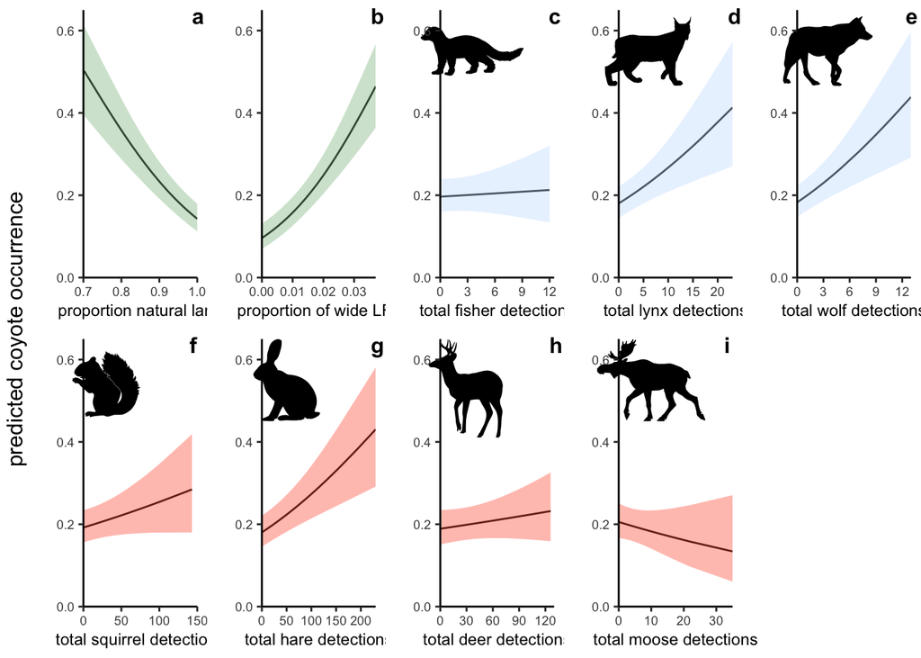

```r
pp_plot <-

  ggarrange(plot_nat_land,
            plot_wide_linear,
            plot_fisher,
            plot_lynx,
            plot_grey_wolf,
            plot_red_squirrel,
            plot_snowshoe_hare,
            plot_white_tailed_deer,
            plot_moose,
            labels = 'auto',
            label.x = 0.88,
            font.label = list(size = 12),
            ncol = 5,
            nrow = 2) %>%

  annotate_figure(left = text_grob('predicted coyote occurrence',
                                   rot = 90,
                                   vjust = 0.5),
                  fig.lab.size = 14)

# run pp_plot to see figure
pp_plot
```

## 9) export predicted probabilities figure

#### save pp_plot to ‘figures’ folder:

```r
ggsave('predicted_probabilities_panel.png',
       pp_plot,
       path = 'figures',
       width = 250,
       height = 100,
       units = 'mm',
       bg = 'white')
```

## 10) predicted probabilities w/ random effects

#### determining and plotting an example graph of predicted probabilities with random effects

#### choosing wide linear features as the fixed effect:

```r
re_pp_wide_linear <-

  ggpredict(global,
            terms = c('wide_linear [all]', # fixed effect
                      'array'), # random effect
            type = "random")
```

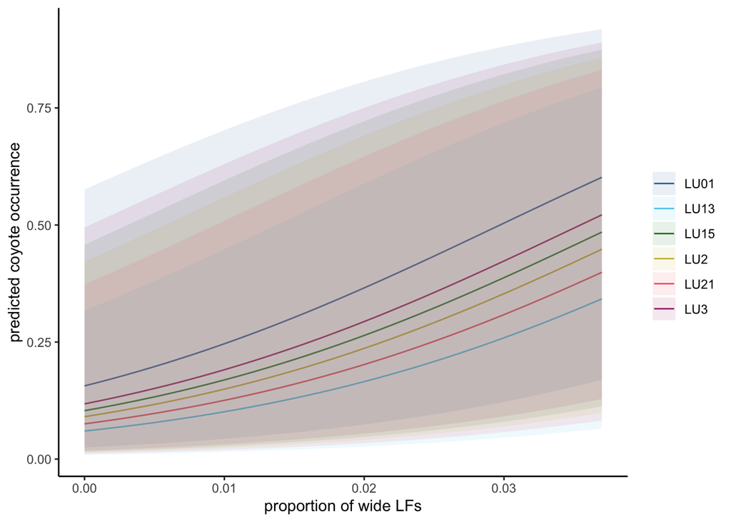

```r
re_plot <-

  ggplot(re_pp_wide_linear,
         aes(x = x,
             y = predicted)) +

  geom_line(aes(color = group)) +

  # using colourblind-friendly Tol colour scheme
  # more info at https://personal.sron.nl/~pault/
  scale_fill_manual(values = c('#4477AA',
                               '#66CCEE',
                               '#228833',
                               '#CCBB44',
                               '#EE6677',
                               '#AA3377')) +

  geom_ribbon(aes(fill = group,
                  ymin = conf.low,
                  ymax = conf.high),
              alpha = 0.1) +

  scale_color_manual(values = c('#4477AA',
                                '#66CCEE',
                                '#228833',
                                '#CCBB44',
                                '#EE6677',
                                '#AA3377')) +

  labs(color = NULL,
       fill = NULL,
       x = 'proportion of wide LFs',
       y = 'predicted coyote occurrence')

# run re_plot to see figure
re_plot
```

#### save plot:

```r
ggsave('re_predicted_probability.png',
       re_plot,
       path = 'figures',
       width = 183,
       height = 100,
       units = 'mm')
```